# TS_HW3_Liang_Gong

2025-02-08

## 5.2 Use the Facebook stock price (data set gafa_stock) to do the following:

## a. Produce a time plot of the series.

```r
library(fpp3)
library(dplyr)
```

```r
# Load the dataset from fpp3
data("gafa_stock")

view(gafa_stock)
```

```r
structure(gafa_stock)
```

```
## # A tsibble: 5,032 x 8 [!]
## # Key:       Symbol [4]
##    Symbol Date        Open  High   Low Close Adj_Close    Volume
##    <chr>  <date>     <dbl> <dbl> <dbl> <dbl>     <dbl>     <dbl>
##  1 AAPL   2014-01-02  79.4  79.6  78.9  79.0      67.0  58671200
##  2 AAPL   2014-01-03  79.0  79.1  77.2  77.3      65.5  98116900
##  3 AAPL   2014-01-06  76.8  78.1  76.2  77.7      65.9 103152700
##  4 AAPL   2014-01-07  77.8  78.0  76.8  77.1      65.4  79302300
##  5 AAPL   2014-01-08  77.0  77.9  77.0  77.6      65.8  64632400
##  6 AAPL   2014-01-09  78.1  78.1  76.5  76.6      65.0  69787200
##  7 AAPL   2014-01-10  77.1  77.3  75.9  76.1      64.5  76244000
##  8 AAPL   2014-01-13  75.7  77.5  75.7  76.5      64.9  94623200
##  9 AAPL   2014-01-14  76.9  78.1  76.8  78.1      66.1  83140400
## 10 AAPL   2014-01-15  79.1  80.0  78.8  79.6      67.5  97909700
## # ℹ 5,022 more rows
```

```r
# Filter for Facebook stock
fb_stock <- gafa_stock %>%
  filter(Symbol == "FB")

view(fb_stock)
```

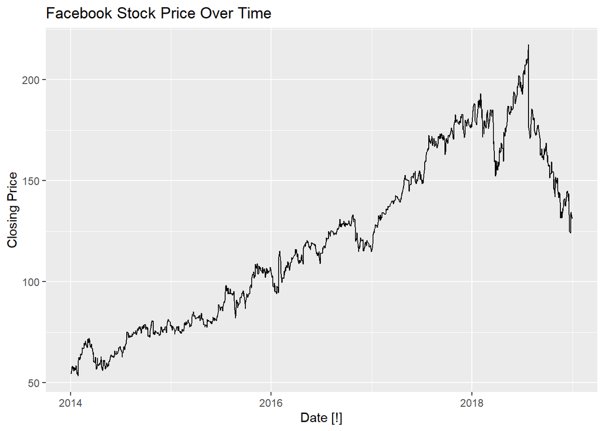

```r
# Time plot of the Closing Price
autoplot(fb_stock, Close) +
  labs(title = "Facebook Stock Price Over Time", y = "Closing Price")
```

## b. Produce forecasts using the drift method and plot them.

The plot shows a forecasted trend extending the historical data using the drift method, which assumes future stock prices will change at the same average rate as observed. A solid forecast line is accompanied by 80% and 95% confidence intervals, represented by darker and lighter shaded areas, respectively. This simple method extrapolates the trend from the first to the last data point, assuming a linear continuation without considering external factors or complex patterns.

```r
# Re-index based on trading days for Facebook stock
fb_stock <- gafa_stock |>
  filter(Symbol == "FB") |>
  # Creates a new column day that assigns a sequential number to each row (representing trading days).
  mutate(day = row_number()) |>
  # Updates the tsibble to use day as the new index and ensures that the index is treated as a regular time series (i.e., sequential without gaps)
  update_tsibble(index = day, regular = TRUE)

view(fb_stock)
```

```r
# Fit the drift model
fb_fit <- fb_stock |>
  model(Drift = RW(Close ~ drift()))

fb_fit
```

```
## # A mable: 1 x 2
## # Key:     Symbol [1]
##   Symbol         Drift
##   <chr>        <model>
## 1 FB     <RW w/ drift>
```

```r
# Produce forecasts for the trading days in the first month after the last date in the data
fb_fc <- fb_fit |>
  forecast(h = 30)

view(fb_fc)
```

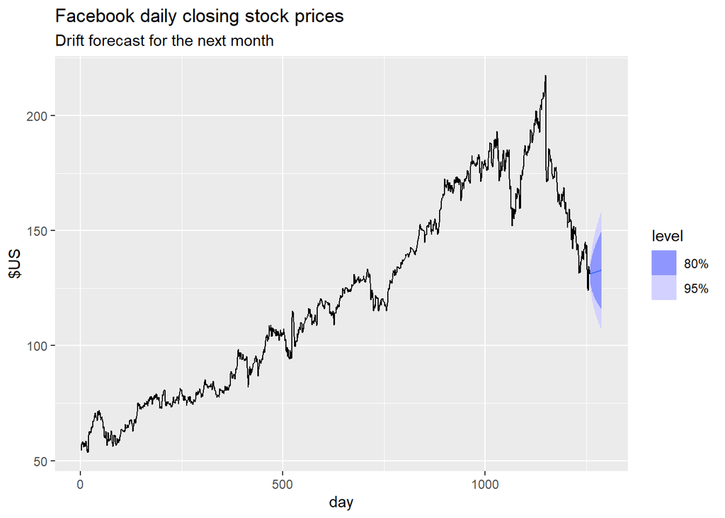

```r
# Plot the forecasts
fb_fc |>
  autoplot(fb_stock, level = c(80, 95)) +
  labs(y = "$US",
       title = "Facebook daily closing stock prices",
       subtitle = "Drift forecast for the next month") +
  guides(colour = guide_legend(title = "Forecast"))
```

Another quick way to write

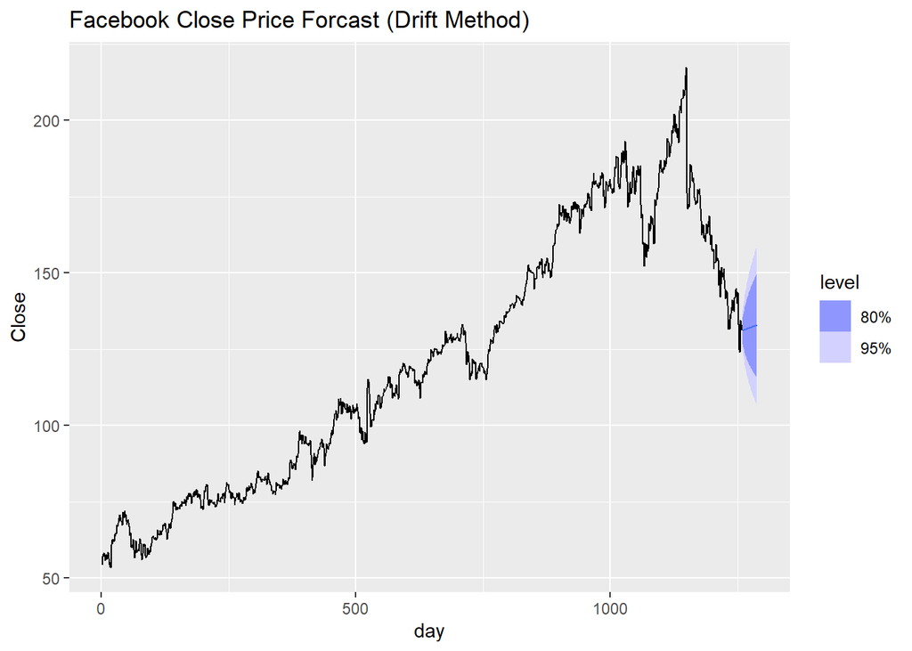

```r
fb_stock %>%
model(Drift = RW(Close ~ drift())) %>%
  forecast(h = 30) %>%
  autoplot(fb_stock) +
    labs(title = "Facebook Close Price Forcast (Drift Method)")
```

## c. Show that the forecasts are identical to extending the line drawn between the first and last observations.

The plot includes blue-shaded areas representing 80% and 95% prediction intervals, with the narrower 80% interval indicating higher confidence and the wider 95% interval accounting for more uncertainty. The forecast line extends the historical trend using the drift method, which assumes future stock prices will change at the same average rate as observed. This simple approach extrapolates a straight-line trend from the first to the last data point without considering external factors that may influence stock prices.

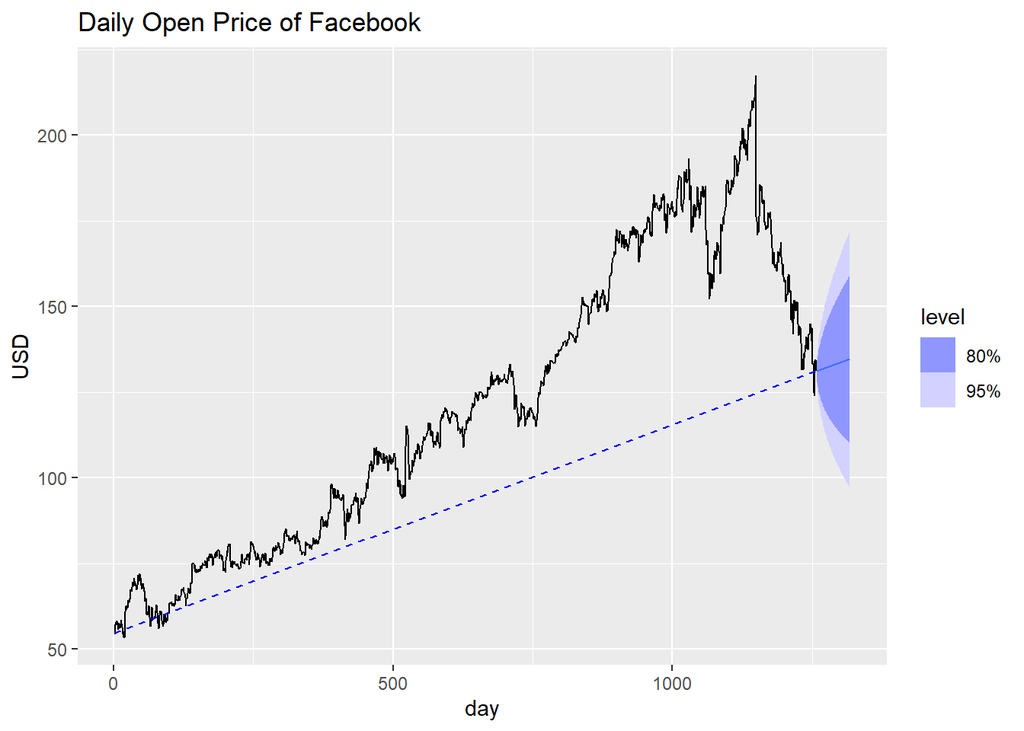

```r
fb_stock %>%
  model(RW(Close ~ drift())) %>%
  forecast(h = 60) %>%
  autoplot(fb_stock) +
  labs(title = "Daily Open Price of Facebook", y = "USD") +
  geom_segment(aes(x = 1, y = 54.71, xend = 1258, yend = 131.09),
               colour = "blue", linetype = "dashed")
```

## d. Try using some of the other benchmark functions to forecast the same data set. Which do you think is best? Why?

The Drift model captures some of the trend, making it more suitable for stock prices, where trends are expected over time.

The Mean model ignores trends and recent movements, making it less useful in this context.

The Naive model may work for short-term forecasts but fails to capture the underlying trend.

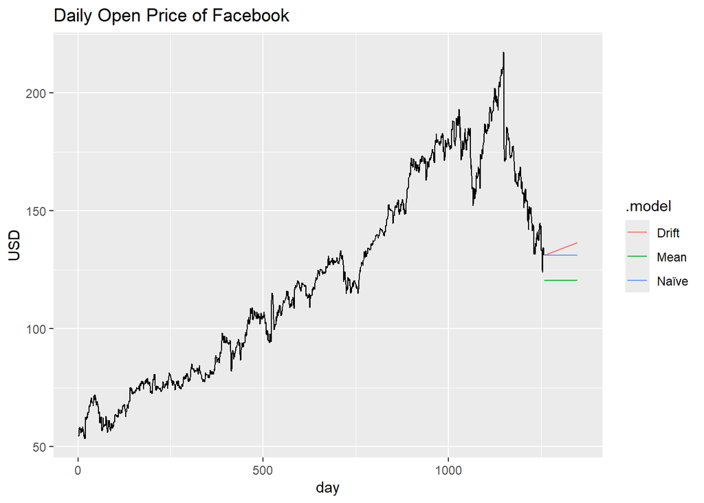

```r
fb_stock %>%
  model(Mean = MEAN(Close),
        `Naïve` = NAIVE(Close),
        Drift = NAIVE(Close ~ drift())) %>%
  forecast(h = 90) %>%
  autoplot(fb_stock, level = NULL) +
  labs(title = "Daily Open Price of Facebook", y = "USD")
```

## 5.9

## a. Create a training set for household wealth (hh_budget) by withholding the last four years as a test set.

```r
view(hh_budget)
```

```r
max(hh_budget$Year)
```

```
## [1] 2016
```

```r
# Define the last year of training
last_training_year <- max(hh_budget$Year) - 4

# Create the training set (all data up to and including 2012)
hh_train <- hh_budget |>
  filter(Year <= last_training_year) |>
  select(Year, Wealth)

# Create the test set (2013, 2014, 2015, 2016)
hh_test <- hh_budget |>
  filter(Year > last_training_year) |>
  select(Year, Wealth)
```

```r
view(hh_train)
```

```r
view(hh_test)
```

## b. Fit all the appropriate benchmark methods to the training set and forecast the periods covered by the test set.

### Mean Model (MEAN): Forecasts future values as the average of past values.

### Naive Model (NAIVE): Assumes future values will be the same as the last observed value.

### Drift Model (RW(Wealth ~ drift())): Assumes the trend continues at the same average rate as in the past.

### The grouping is inferred automatically because hh_train is a tsibble with Country as a key variable. This allows model() to fit separate models for each country without explicitly specifying it in the code.

```r
# Fit benchmark models on the training set for each country
hh_models <- hh_train |>
  model(
    Mean = MEAN(Wealth),
    Naive = NAIVE(Wealth),
    Drift = RW(Wealth ~ drift())
  )

# Forecast for 2013, 2014, 2015, 2016
hh_forecasts <- hh_models |>
  forecast(h = 4)
```

```r
view(hh_forecasts)
```

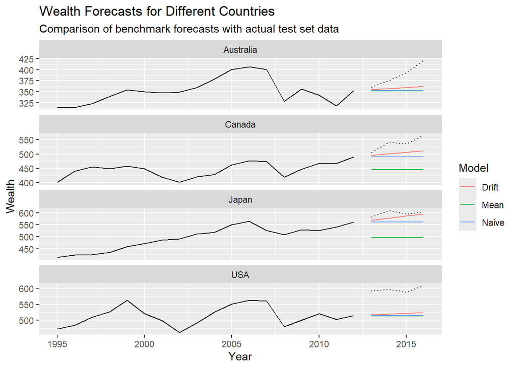

```r
# Plot the forecasts and compare with actual values in the test set for each country
hh_forecasts |>
  # Plots the forecasted values along with the training data.
  autoplot(hh_train, level = NULL) +
  # Adds actual test data (hh_test) as a dotted black line to compare against the forecasts.
  autolayer(hh_test, Wealth, color = "black", linetype = "dotted") +
  # Adds a title, subtitle, and axis labels for clarity.
  labs(title = "Wealth Forecasts for Different Countries",
       y = "Wealth",
       subtitle = "Comparison of benchmark forecasts with actual test set data") +
  # Adds a legend to differentiate forecast models.
  # Specifies that the legend should be based on the color aesthetic.
  guides(colour = guide_legend(title = "Model"))
```

## c. Compute the accuracy of your forecasts. Which method does best?

The **Drift model** is the best-performing model based on the **lowest Root Mean Square Error (RMSE) of 41.69**. RMSE is a commonly preferred metric because it **penalizes larger errors more heavily**, making it particularly useful for evaluating time series forecasting models. Looking at the chart “Wealth Forecasts for Different Countries” above, it can also tell that **Drift model** is the best-performing model since its line is closet to test data.

```r
# Calculate accuracy metrics by comparing forecasts with actual values in hh_test
accuracy_results <- hh_forecasts |>
  accuracy(hh_test)

# Display the accuracy metrics
print(accuracy_results)
```

```
## # A tibble: 12 × 11
##    .model Country   .type    ME  RMSE   MAE   MPE  MAPE  MASE RMSSE    ACF1
##    <chr>  <chr>     <chr> <dbl> <dbl> <dbl> <dbl> <dbl> <dbl> <dbl>   <dbl>
##  1 Drift  Australia Test   29.1  35.5  29.1  7.23  7.23   NaN   NaN  0.210
##  2 Drift  Canada    Test   33.3  37.2  33.3  6.09  6.09   NaN   NaN -0.229
##  3 Drift  Japan     Test   14.7  17.9  14.7  2.44  2.44   NaN   NaN -0.229
##  4 Drift  USA       Test   75.9  76.2  75.9 12.7  12.7    NaN   NaN -0.561
##  5 Mean   Australia Test   35.7  42.3  35.7  8.89  8.89   NaN   NaN  0.216
##  6 Mean   Canada    Test   90.4  92.9  90.4 16.7  16.7    NaN   NaN -0.0799
##  7 Mean   Japan     Test  100.  101.  100.  16.8  16.8    NaN   NaN -0.534
##  8 Mean   USA       Test   82.9  83.3  82.9 13.9  13.9    NaN   NaN -0.423
##  9 Naive  Australia Test   34.7  41.5  34.7  8.64  8.64   NaN   NaN  0.216
## 10 Naive  Canada    Test   46.2  51.0  46.2  8.46  8.46   NaN   NaN -0.0799
## 11 Naive  Japan     Test   36.3  37.8  36.3  6.06  6.06   NaN   NaN -0.534
## 12 Naive  USA       Test   82.1  82.5  82.1 13.8  13.8    NaN   NaN -0.423
```

```r
# Group accuracy metrics by model (.model) and calculates the average of three key error metrics—MAE (Mean Absolute Error), RMSE (Root Mean Squared Error), and MAPE (Mean Absolute Percentage Error)—to compare model performance.
accuracy_summary <- accuracy_results |>
  group_by(.model) |>
  summarise(
    MAE = mean(MAE),
    RMSE = mean(RMSE),
    MAPE = mean(MAPE)
  )

print("Summary of accuracy metrics by model:")
```

```
## [1] "Summary of accuracy metrics by model:"
```

```r
print(accuracy_summary)
```

```
## # A tibble: 3 × 4
##   .model   MAE  RMSE  MAPE
##   <chr>  <dbl> <dbl> <dbl>
## 1 Drift   38.2  41.7  7.12
## 2 Mean    77.3  79.9 14.1
## 3 Naive   49.8  53.2  9.23
```

## d. Do the residuals from the best method resemble white noise?

The **ACF plots** show minimal autocorrelation across most lags, with values largely within the confidence bands (dashed blue lines), indicating no strong autocorrelation in the residuals.

The **Ljung-Box test p-values** for all four countries are relatively high (above 0.05), meaning we **fail to reject the null hypothesis** of no autocorrelation. This suggests that the residuals exhibit white noise behavior at the commonly used significance level (0.05).

While minor fluctuations and small autocorrelation spikes appear in the **ACF plot**, the high p-values from the **Ljung-Box test** reinforce that the residuals resemble white noise.

Overall, the **Drift model** effectively captures the main trend in household wealth data, as indicated by the lack of significant residual autocorrelation.

### Residual analysis should be based on the training fit to validate the model, while test set errors evaluate forecasting performance.I will fit the best Drift method only to the training dataset to obtain residuals

```
## Plot variable not specified, automatically selected `.vars = .resid`
```

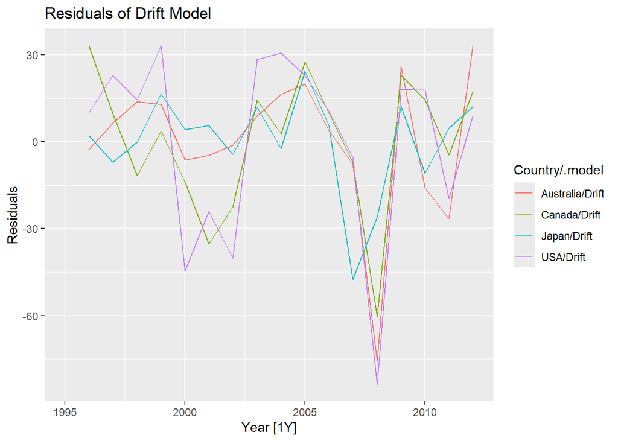

```r
# Fit the Drift model on the training set
drift_model <- hh_train |>
  model(Drift = RW(Wealth ~ drift()))

# Calculate residuals from the drift model
drift_residuals <- residuals(drift_model)

# Plot the residuals to visually inspect for white noise
autoplot(drift_residuals) +
  labs(title = "Residuals of Drift Model", y = "Residuals")
```

```
## Response variable not specified, automatically selected `var = .resid`
```

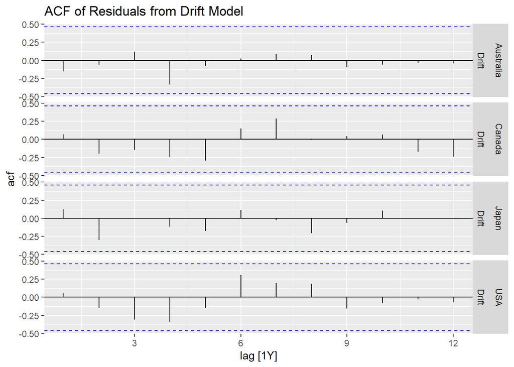

```r
# Plot the ACF of the residuals to check for autocorrelation
ACF(drift_residuals) |>
  autoplot() +
  labs(title = "ACF of Residuals from Drift Model")
```

```r
# Perform Ljung-Box test to check if residuals resemble white noise
ljung_box_test <- drift_residuals |>
  features(.resid, ljung_box, lag = 10, dof = 0)

# Display the Ljung-Box test results
print("Ljung-Box Test Results:")
```

```
## [1] "Ljung-Box Test Results:"
```

```r
print(ljung_box_test)
```

```
## # A tibble: 4 × 4
##   Country   .model lb_stat lb_pvalue
##   <chr>     <chr>    <dbl>     <dbl>
## 1 Australia Drift     4.82     0.903
## 2 Canada    Drift     8.87     0.545
## 3 Japan     Drift     6.09     0.807
## 4 USA       Drift    12.9      0.229
```

## Alternatively, use gg_tsresiduals()

```
## [1] "Residual diagnostics for: Australia"
```

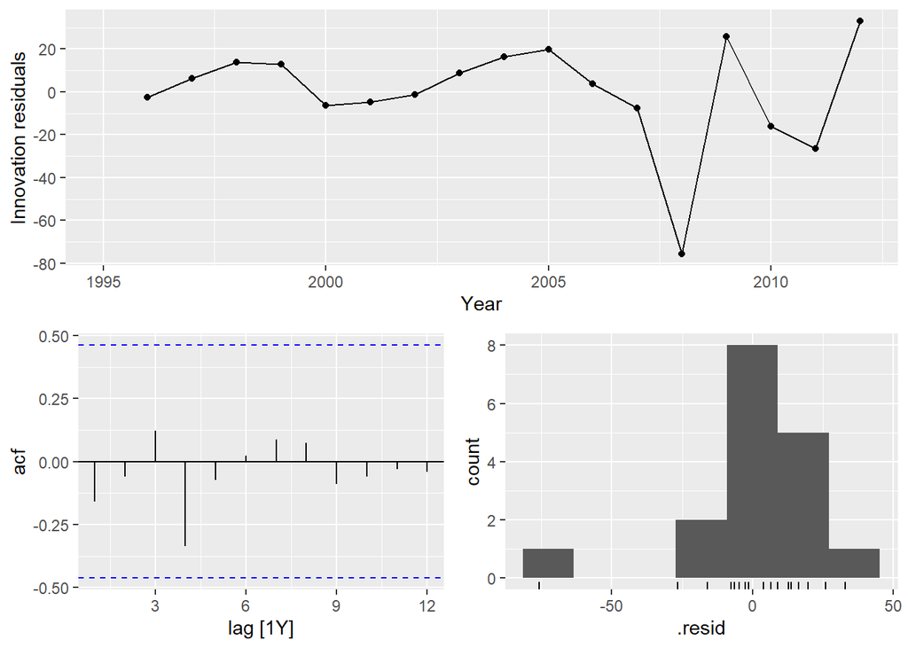

```
## [1] "Residual diagnostics for: Canada"
```

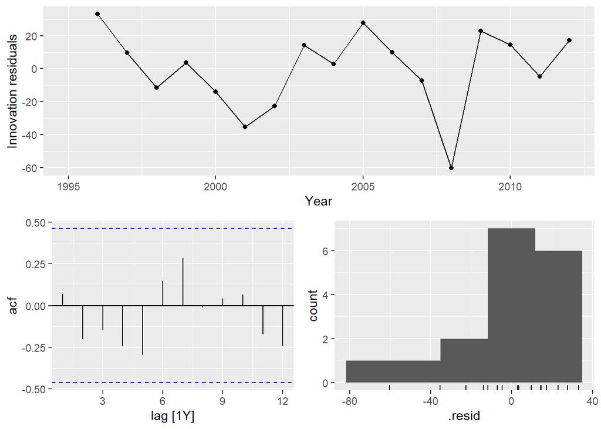

```
## [1] "Residual diagnostics for: Japan"
```

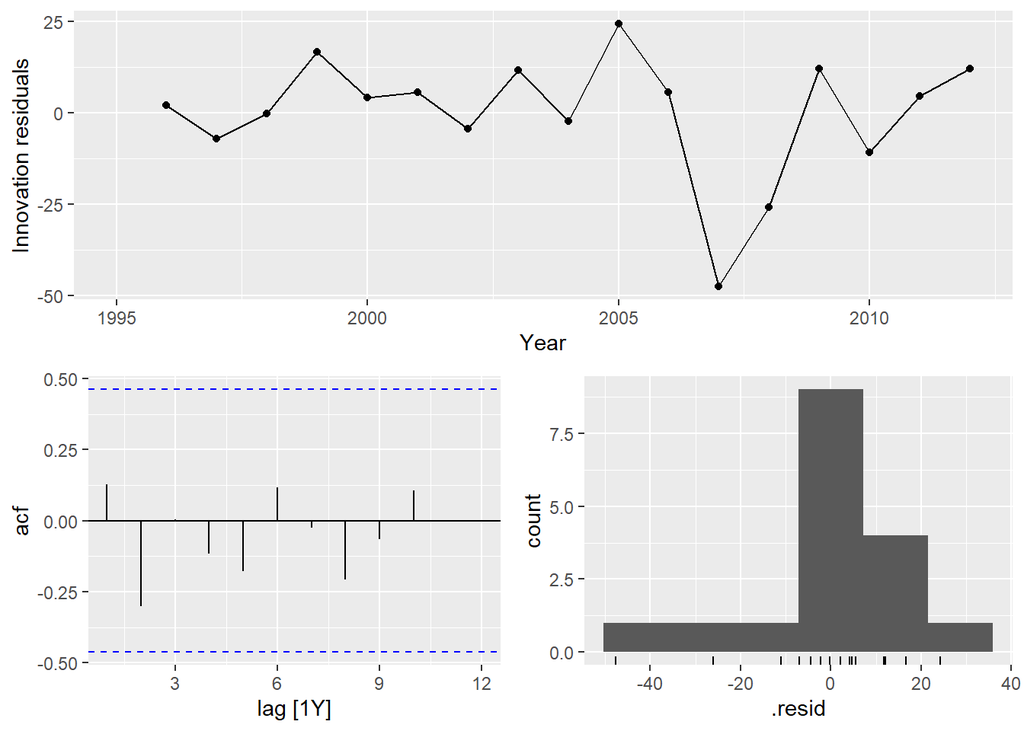

```
## [1] "Residual diagnostics for: USA"
```

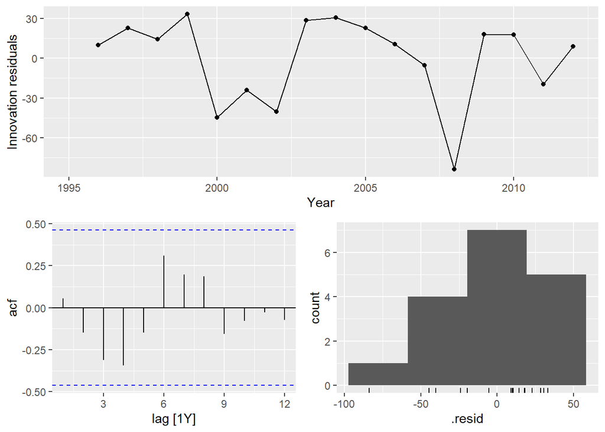

```r
# Get a list of unique countries
countries <- unique(hh_train$Country)

# Loop through each country and plot residual diagnostics
for (c in countries) {
  print(paste("Residual diagnostics for:", c))
  print(gg_tsresiduals(drift_model %>% filter(Country == c)))
}
```